# Variable Importance

Liang

14/03/2022

### Introduction

In regression models, the relative importance of predictors can be determine in various ways, e.g., by comparing p-values and confidence intervals. With classification and regression trees (CARTs), determining variable importance is less straight forward. In this document, we will explore ways to calculate variable importance for simple CARTs as well as more complex variations such as bagging, random forest and boosting. The right heart catheterization (RHC) data will be used to demonstrate the process of calculating variable importance for tree-based methods.

##### Data cleaning

The dataset is prepared following the steps outlined in “R Guide for TMLE in Medical Research” (https://ehsanx.github.io/TMLEworkshop/).

```r
rhcdata <- read.csv("rhc.csv") # load data

# add column for outcome Y: length of stay
# Y = date of discharge - study admission date
# Y = date of death - study admission date if date of discharge not available
rhcdata$Y <- rhcdata$dschdte - rhcdata$sadmdte
rhcdata$Y[is.na(rhcdata$Y)] <- rhcdata$dthdte[is.na(rhcdata$Y)] -
  rhcdata$sadmdte[is.na(rhcdata$Y)]
# remove outcomes we are not examining in this example
rhcdata <- dplyr::select(rhcdata,
                         !c(dthdte, lstctdte, dschdte, death, t3d30, dth30, surv2md1))
# remove unnecessary and problematic variables
rhcdata <- dplyr::select(rhcdata,
                         !c(sadmdte, ptid, X, adld3p, urin1, cat2))

# convert all categorical variables to factors
factors <- c("cat1", "ca", "cardiohx", "chfhx", "dementhx", "psychhx",
             "chrpulhx", "renalhx", "liverhx", "gibledhx", "malighx",
             "immunhx", "transhx", "amihx", "sex", "dnr1", "ninsclas",
             "resp", "card", "neuro", "gastr", "renal", "meta", "hema",
             "seps", "trauma", "ortho", "race", "income")
rhcdata[factors] <- lapply(rhcdata[factors], as.factor)
# convert our treatment A (RHC vs. No RHC) to a binary variable
rhcdata$A <- ifelse(rhcdata$swang1 == "RHC", 1, 0)
rhcdata <- dplyr::select(rhcdata, !swang1)
# Categorize the variables to match with the original paper
rhcdata$age <- cut(rhcdata$age,breaks=c(-Inf, 50, 60, 70, 80, Inf),right=FALSE)
rhcdata$race <- factor(rhcdata$race, levels=c("white","black","other"))
rhcdata$sex <- as.factor(rhcdata$sex)
rhcdata$sex <- relevel(rhcdata$sex, ref = "Male")
rhcdata$cat1 <- as.factor(rhcdata$cat1)
levels(rhcdata$cat1) <- c("ARF","CHF","Other","Other","Other",
                          "Other","Other","MOSF","MOSF")
rhcdata$ca <- as.factor(rhcdata$ca)
levels(rhcdata$ca) <- c("Metastatic","None","Localized (Yes)")
rhcdata$ca <- factor(rhcdata$ca, levels=c("None",
                                          "Localized (Yes)","Metastatic"))

# Rename variables
names(rhcdata) <- c("Disease.category", "Cancer", "Cardiovascular",
                    "Congestive.HF", "Dementia", "Psychiatric", "Pulmonary",
                    "Renal", "Hepatic", "GI.Bleed", "Tumor",
                    "Immunosupperssion", "Transfer.hx", "MI", "age", "sex",
                    "edu", "DASIndex", "APACHE.score", "Glasgow.Coma.Score",
                    "blood.pressure", "WBC", "Heart.rate", "Respiratory.rate",
                    "Temperature", "PaO2vs.FIO2", "Albumin", "Hematocrit",
                    "Bilirubin", "Creatinine", "Sodium", "Potassium", "PaCo2",
                    "PH", "Weight", "DNR.status", "Insurance",
                    "Respiratory.Diag", "Cardiovascular.Diag",
                    "Neurological.Diag", "Gastrointestinal.Diag", "Renal.Diag",
                    "Metabolic.Diag", "Hematologic.Diag", "Sepsis.Diag",
                    "Trauma.Diag", "Orthopedic.Diag", "race", "income",
                    "Y", "A")

levels(rhcdata$Insurance) = c("Medicaid", "Medicare", "M&M", "None", "Priv", "Priv&Medicare")
```

#### CARTs

With CARTs, one way to gauge variable importance is to compare the extent to which variables reduce variation in the response, also referred to as ‘node impurity’. Since one variable can be chosen more than once as the split variable, the reductions in variation are aggregated over all splits.

Start with constructing a regression tree for the RHC dataset.

```r
# "Y" is the response variable
resp = "Y"; data = rhcdata

# create data.drame to store outputs
output = data.frame(status = "split", count = nrow(data), "split rule" = "root", iter = 0, mean = mean(data[, resp]), stringsAsFactors = FALSE)
```

For simplicity, we consider three variables, ‘Albumin’, ‘Cardiovascular’ and ‘Disease.category’ for the model.

```r
# create vector of variables to be used for building the tree
feat = c("Albumin", "Cardiovascular", "Disease.category")
```

```r
# set minimum observation per parent node. The value is large in order to guarantee a simple model with few splits.
min.obs = 2000

# set minimum node size. The same value is used as the default setting in rpart
leafsize = min.obs/3

# empty objects for later use
weighted.sd = c()
error = c()
split_val = list()

# For each feature of interest, determine the optimal split
for (i in 1:length(feat)){
  data_sub = data.frame(var = data[, feat[i]], resp = data[, resp])

  # calculating sse for categorical feature:
  if(is.factor(data_sub$var)) {

    if( length(levels(data_sub$var)) > 2 ){
      # if more than 2 levels find all possible binary splits
      kk = 1
      varcomb = list()
      for (ii in 1:(length(levels(data_sub$var))-1)) {
        comb = combn(length(levels(data_sub$var)), ii)
        for (jj in 1:ncol(comb)){
          varcomb[[kk]] = levels(data_sub$var)[comb[, jj]]
          kk = kk +1
        }
      }

      # calculate sse for all possible splits
      sse = sapply(varcomb, function(varcomb_i){
        sum((data_sub$resp[data_sub$var %in% varcomb_i] - mean(data_sub$resp[data_sub$var %in% varcomb_i]))^2) + sum((data_sub$resp[!(data_sub$var %in% varcomb_i)] - mean(data_sub$resp[!(data_sub$var %in% varcomb_i)]))^2) })

      # checking size of children nodes; if less than specified by 'leafsize', the split is not considered
      count_min = sapply(varcomb, function(varcomb_i){min(length(data_sub$resp[data_sub$var %in% varcomb_i]), length(data_sub$resp[!(data_sub$var %in% varcomb_i)]))})
      for(ii in 1:length(varcomb)) {if(count_min[ii] < round(leafsize)) sse[ii] = NA}

      # clean up:
      if(all(is.na(sse))) {error[i] = NA; split_val[[i]] = NA} else { error[i] = min(sse, na.rm = TRUE); split_val[[i]] = varcomb[[which.min(sse)]]}

    } else {
      # if only two levels
      data.split = split(data_sub, data_sub$var)
      error[i] = sum(sapply(data.split, function(x){
        sum( (x$resp - mean(x$resp)) ^ 2 )
      }))

        # checking size of children nodes; if less than specified by 'leafsize', the split is not considered
        count_min = min(sapply(data.split, nrow))
        if( count_min < leafsize) error[i] = NA
    }

    # calculating sse for continuous feature:
  } else {
    splits_sort = sort(unique(data_sub$var)) # all possible splits
    sse <- c()

    # calculating sse for all possible splits
    for( k in 1:length(splits_sort)){
      sse[k] = sum( (data_sub$resp[data_sub$var < splits_sort[k]] - mean(data_sub$resp[data_sub$var < splits_sort[k]]) )^2 ) + sum( (data_sub$resp[data_sub$var >= splits_sort[k]] - mean(data_sub$resp[data_sub$var >= splits_sort[k]]) )^2 )

      # checking size of children nodes; if less than specified, the split is not considered
      count_min = min(length(data_sub$resp[data_sub$var < splits_sort[k]]), length(data_sub$resp[data_sub$var >= splits_sort[k]]))
      if(count_min < round(leafsize)) sse[k] = NA
    }
    # clean up for when none of the splits is valid:
    if(all(is.na(sse))) {error[i] = NA; split_val[[i]] = NA} else { error[i] = min(sse, na.rm = TRUE); split_val[[i]] = splits_sort[which.min(sse)]}
  }
}


if(all(is.na(error))){
  # if none of the splits is good, set the current node to 'leaf'
  output$status[j] = "leaf"
} else {
  # otherwise proceed with the split and choose the feature leading to the lowest sse
  splitvar = feat[which.min(error)]
}
splitvar
```

```
## [1] "Disease.category"
```

Note that the sum of squared errors (SSE) for the parent node is:

```r
rss_parent = sum((data[,resp] - mean(data[,resp]))^2)
rss_parent
```

```
## [1] 3836690
```

The SSE after the split is:

```r
min(error, na.rm = TRUE)
```

```
## [1] 3765678
```

The variable ‘Disease.category’ reduced the SSE of the parent node by:

```r
diff = rss_parent - min(error, na.rm = TRUE)
diff
```

```
## [1] 71011.63
```

Repeat the above steps but this time with a loop to complete the tree.

```r
regtree <- function(data, resp, min.obs, feat){
  stopsplit = FALSE
  data.list = list()
  data.list[[1]] = rhcdata
  varimp = data.frame()
  iter = 1
  leafsize = min.obs/3
  output = data.frame(status = "split", count = nrow(data), "split rule" = "root", iter = 0, mean = mean(data[, resp]), stringsAsFactors = FALSE)
  while(!stopsplit) {
    # list of splits to be done:
      split.queue = which(output$status == "split")

      for (j in split.queue[1]) {
        # load data corresponding to current node
        data.temp = data.list[[j]]

      # For each feature of interest, determine the optimal split
      for (i in 1:length(feat)){
        data_sub = data.frame(var = data.temp[, feat[i]], resp = data.temp[, resp])

        # calculating sse for categorical feature:
        if(is.factor(data_sub$var)) {

          if( length(levels(data_sub$var)) > 2 ){
            # if more than 2 levels find all possible binary splits
            kk = 1
            varcomb = list()
            for (ii in 1:(length(levels(data_sub$var))-1)) {
              comb = combn(length(levels(data_sub$var)), ii)
              for (jj in 1:ncol(comb)){
                varcomb[[kk]] = levels(data_sub$var)[comb[, jj]]
                kk = kk +1
              }
            }

            # calculate sse for all possible splits
            sse = sapply(varcomb, function(varcomb_i){
              sum((data_sub$resp[data_sub$var %in% varcomb_i] - mean(data_sub$resp[data_sub$var %in% varcomb_i]))^2) + sum((data_sub$resp[!(data_sub$var %in% varcomb_i)] - mean(data_sub$resp[!(data_sub$var %in% varcomb_i)]))^2) })

            # checking size of children nodes; if less than specified by 'leafsize', the split is not considered
            count_min = sapply(varcomb, function(varcomb_i){min(length(data_sub$resp[data_sub$var %in% varcomb_i]), length(data_sub$resp[!(data_sub$var %in% varcomb_i)]))})
            for(ii in 1:length(varcomb)) {if(count_min[ii] < round(leafsize)) sse[ii] = NA}

            # clean up:
            if(all(is.na(sse))) {error[i] = NA; split_val[[i]] = NA} else { error[i] = min(sse, na.rm = TRUE); split_val[[i]] = varcomb[[which.min(sse)]]}

          } else {
            # if only two levels
            data.split = split(data_sub, data_sub$var)
            error[i] = sum(sapply(data.split, function(x){
              sum( (x$resp - mean(x$resp)) ^ 2 )
            }))

              # checking size of children nodes; if less than specified by 'leafsize', the split is not considered
              count_min = min(sapply(data.split, nrow))
              if( count_min < leafsize) error[i] = NA
          }

          # calculating sse for continuous feature:
        } else {
          splits_sort = sort(unique(data_sub$var)) # all possible splits
          sse <- c()

          # calculating sse for all possible splits
          for( k in 1:length(splits_sort)){
            sse[k] = sum( (data_sub$resp[data_sub$var < splits_sort[k]] - mean(data_sub$resp[data_sub$var < splits_sort[k]]) )^2 ) + sum( (data_sub$resp[data_sub$var >= splits_sort[k]] - mean(data_sub$resp[data_sub$var >= splits_sort[k]]) )^2 )

            # checking size of children nodes; if less than specified, the split is not considered
            count_min = min(length(data_sub$resp[data_sub$var < splits_sort[k]]), length(data_sub$resp[data_sub$var >= splits_sort[k]]))
            if(count_min < round(leafsize)) sse[k] = NA
          }
          # clean up for when none of the splits is valid:
          if(all(is.na(sse))) {error[i] = NA; split_val[[i]] = NA} else { error[i] = min(sse, na.rm = TRUE); split_val[[i]] = splits_sort[which.min(sse)]}
        }
      }


      if(all(is.na(error))){
        # if none of the splits is good, set the current node to 'leaf'
        output$status[j] = "leaf"
      } else {
        # otherwise proceed with the split and choose the feature leading to the lowest sse
        splitvar = feat[which.min(error)]

        # creating children nodes:
            if( is.factor(data.temp[[splitvar]])) {
              # for categorical feature:

              if( length(levels(data.temp[[splitvar]])) > 2 ){
                yeslevels = split_val[[which.min(error)]]
                nolevels = unique(data.temp[[splitvar]])[!(unique(data.temp[[splitvar]]) %in% yeslevels)]
                children = list()
                children[[1]] = data.temp[data.temp[[splitvar]] %in% nolevels, ]
                children[[2]] = data.temp[data.temp[[splitvar]] %in% yeslevels, ]
              } else children = split(data.temp, data.temp[ , splitvar])
            } else {
              # for continuous feature:
              value = split_val[[which.min(error)]]
              index = which(sort(unique(data.temp[[splitvar]])) == value)
              # taking the middle point of unique values as the splitting point to be consistent with 'rpart':
              value = (sort(unique(data.temp[[splitvar]]))[index] + sort(unique(data.temp[[splitvar]]))[index-1])/2
              children = list()
              children[[1]] = data.temp[which(data.temp[[splitvar]] <= value), ]
              children[[2]] = data.temp[which(data.temp[[splitvar]] > value), ]
            }

     # Stopping criteria:
            # - less than 3 observations
            # - all observations have the same label
            status = sapply(children, function(x){
              if (ncol(x) > 2) {
                if (nrow(x) < min.obs | nrow( unique(x[, -which(names(x) %in% resp)]) ) == 1) status = "leaf" else status = "split"
              } else status = "leaf"

              status
            })
      # change current status from 'split' to 'parent' so it won't be split further:
            output$status[j] = "parent"

      # record how the split was done:
      if( is.factor(data.temp[[splitvar]]) ) {
        if( length(levels(data.temp[[splitvar]])) > 2 ){
          splitrule = c(paste(splitvar, "in", paste(nolevels, collapse = ",")), paste(splitvar, "in", paste(yeslevels, collapse = ",")) )
        } else splitrule = sapply(names(children), function(x){paste(splitvar, "=" , x)})
      } else {
        splitrule = c(paste(splitvar, "<=", value),paste(splitvar, ">", value) )
      }

      # creating outputs
      temp.output = data.frame(status = status, count = sapply(children, nrow), "split rule" = splitrule, iter = output$iter[j] + 1, row.names = NULL, mean = sapply(children, function(x){mean(x[,resp])}))

      # reduction in sse for variable importance
      sse_parent = sum((data.temp[,resp] - mean(data.temp[,resp]))^2)
      diff = sse_parent - min(error, na.rm = TRUE)
      temp.varimp =  data.frame(variable = splitvar, diff_sse = diff)

      # attach new outputs to existing dataframes
      output = rbind(output[1:j,], temp.output, output[-c(1:j), ])
      names(children) = NULL; data.list = c(data.list[1:j], children, data.list[-c(1:j)])

      varimp = rbind(varimp, temp.varimp)
      }
    }
      # check if there are remaining splits to be done:
      if(all(output$status != "split")) stopsplit = TRUE
  }
  return(list(output = output, varimp = varimp))
}
res = regtree(data = rhcdata, resp = "Y", min.obs = min.obs, feat = c("Disease.category", "Albumin", "Cardiovascular"))
```

```r
res$output
```

```
##   status count                    split.rule iter     mean
## 1 parent  5735                          root    0 21.55937
## 2   leaf  1619 Disease.category in Other,CHF    1 15.94873
## 3 parent  4116  Disease.category in ARF,MOSF    1 23.76628
## 4   leaf   734         Albumin <= 2.24975585    2 29.30109
## 5 parent  3382          Albumin > 2.24975585    2 22.56505
## 6   leaf  1248      Disease.category in MOSF    3 24.05929
## 7 parent  2134       Disease.category in ARF    3 21.69119
## 8   leaf   834         Albumin <= 3.44995115    4 22.67026
## 9   leaf  1300          Albumin > 3.44995115    4 21.06308
```

The reductions in SSE over each split are as follows:

```r
res$varimp
```

```
##           variable  diff_sse
## 1 Disease.category 71011.629
## 2          Albumin 27365.511
## 3 Disease.category  4416.082
## 4          Albumin  1312.344
```

For each variable, sum up the reductions in SSE over all splits it was involved in.

```r
varimp_sum = c()
for (i in 1:length(feat)){
  varimp_sum[i] = sum(res$varimp$diff_sse[which(res$varimp$variable == feat[i])])
}
```

The relative variable importance is as follows:

```r
data.frame(variable = feat, varimp = varimp_sum)
```

```
##           variable   varimp
## 1          Albumin 28677.86
## 2   Cardiovascular     0.00
## 3 Disease.category 75427.71
```

```r
res_rpart = rpart(Y~Disease.category+Albumin+Cardiovascular, data = rhcdata, minsplit = min.obs, cp=-1)
res_rpart
```

```
## n= 5735
##
## node), split, n, deviance, yval
##       * denotes terminal node
##
##  1) root 5735 3836690.0 21.55937
##    2) Disease.category=CHF,Other 1619  615924.7 15.94873 *
##    3) Disease.category=ARF,MOSF 4116 3149753.0 23.76628
##      6) Albumin>=2.249756 3382 2243847.0 22.56505
##       12) Disease.category=ARF 2134 1219127.0 21.69119
##         24) Albumin>=3.449951 1300  690502.8 21.06308 *
##         25) Albumin< 3.449951 834  527312.3 22.67026 *
##       13) Disease.category=MOSF 1248 1020304.0 24.05929 *
##      7) Albumin< 2.249756 734  878540.5 29.30109 *
```

```r
res_rpart$variable.importance
```

```
## Disease.category          Albumin
##         75427.71         30563.90
```

#### Bagging

Variable importance can be obtained for other tree-based methods, including bagging, random forest. Bagging and random forest involve building a number of different trees, where it is possible to obtain estimates of prediction accuracy with internal validation. In addition to the approach shown above for assessing variable importance through tracking reductions in ‘node impurity’ or heterogeneity in the data, one can also obtain measures of variable importance via prediction accuracy. Permuting the values of an important predictor should compromise the prediction accuracy of the model. To demonstrate this, we will apply bootstrap aggregation (bagging) to the RHC dataset.

Let ‘n.boot’ be the number of bootstrap samples.

```r
n.boot = 100
```

The following are functions to generate predictions from the custom outputs.

```r
predtree = function(newdata, resp, res, data){

  # splitting rules from tree:
  rules = data.frame(t(sapply(res$split.rule[-1 ], function(x){scan(text = x, what = "" , quiet = TRUE, )}, USE.NAMES = FALSE)), res$iter[-1], stringsAsFactors = FALSE)
  names(rules) = c("feat", "operator", "value", "iter")

  for(k in 1:nrow(newdata)){

    ii=1
    stoploop = FALSE
    while(!stoploop){
      if(compare(newdata[k, rules[ii, "feat"]], rules[ii, "value"],  (rules[ii, "operator"]))) {
        if(rules$iter[ii+1] == rules$iter[ii]) stoploop = TRUE else ii = ii + 1
      } else {
        ii = which(rules$feat == rules$feat[ii] & rules$iter == rules$iter[ii])[which(rules$feat == rules$feat[ii] & rules$iter == rules$iter[ii]) > ii][1]
      }

      if(rules$iter[ii+1] < rules$iter[ii] | ii == nrow(rules)) stoploop = TRUE
    }

    if(class(data[, resp]) == "factor"){
      newdata[,resp][k] = if(res$prob[ii+1] > 0.5) levels(data[, resp])[1] else { if(res$prob[ii+1] == 0.5) levels(data[, resp])[sample(x = 2, size = 1, prob = c(0.5, 0.5))] else levels(data[, resp])[2]}
    } else {
      newdata[,resp][k] = res$mean[ii+1]
    }
  }
  return(newdata)
}

# helper function:
compare = function(x1,value, operator){
  if(is.factor(x1)) {
    if (length(levels(x1)) > 2) {
      grepl(x1, value, fixed = TRUE)
    }
  } else {
    if(operator == "=") operator = "=="
    if(!is.na(suppressWarnings(as.numeric(value)))) value = as.numeric(value)
    res = getFunction(operator)(x1,value); res }
  }
```

The following function computes the out-of-bag error using the given new dataset and the list of trees.

```r
na.omit.list <- function(y) { return(y[!sapply(y, function(x) all(is.na(x)))]) }

ooberror = function(newdata, index_list, tree_list, data){

  # compute predictions for each obs in the dataset
  for (obs in 1:nrow(data)){
    # for obs i, gather list of trees that weren't built from this obs
    # only those trees will be used to predict
    ifoob = sapply(index_list, function(index){
      !(obs %in% index)
    })

    if(class(data[, resp]) == "factor"){
      # for classification:
      pred_obs = lapply(1:length(tree_list), function(k){
        # generate prediction from tree k if it didn't contain current obs
        if(ifoob[k] == TRUE) data.frame(resp = predtree(newdata = newdata[obs, ], resp = resp, res = tree_list[[k]]$output, data = data)[,resp]) else NA
      })
      pred_obs = na.omit.list(pred_obs)
      pred_obs = do.call(rbind, pred_obs)

      # if no prediction was generated from any tree, set to NA
      if(is.null(pred_obs)) pred[obs] = NA else{
        # other wise, find the majority vote
        pred[obs] = if(table(pred_obs)[1] != table(pred_obs)[2]){
          levels(pred_obs$resp)[which.max(table(pred_obs))]
        } else {
          # If there's no majority, pick randomly with equal probabilities
          levels(pred_obs$resp)[sample(x = 2, size = 1, prob = c(0.5, 0.5))]
        }
      }
    } else {
      # for regression:
      # generate prediction from tree k if it didn't contain current obs
      pred_obs = sapply(1:length(tree_list), function(k){
        if(ifoob[k] == TRUE) predtree(newdata = newdata[obs, ], resp = resp, res = tree_list[[k]]$output, data = data)[,resp] else NA
      })

      # if no prediction was generated from any tree, set to NA. Otherwise, compute the average of predictions
      if (all(is.na(pred_obs))) pred[obs] = NA else pred[obs]  = mean(pred_obs, na.rm = TRUE)

    }

  }
  if(class(data[, resp]) == "factor"){
    # dataframe containing predicted and observed values:
    comb = data.frame(pred, observed = data[,resp])
    comb = na.omit(comb)

    # find the rate of missclassification for classification trees:
    error = mean(comb$pred != comb$observed)
  } else {
    # compute rmse for regression trees:
    error = sqrt(mean( (pred - data[,resp])^2, na.rm = TRUE))
  }

  return(error)
}
environment(ooberror) <- environment()
```

The bagging algorithm:

```r
# empty vectors and lists:
data_list = index_list = list()
pred = c()

# start by drawing 'n.boot' bootstrap samples:
set.seed(123)
for (i in 1:n.boot){
  # index of bootstrap sample:
  index_list[[i]] = sample(nrow(data),  replace = TRUE)

  # ith bootstrap sample:
  data_list[[i]] =data[index_list[[i]], ]
}

# list of trees for each bootstrap sample
tree_list = lapply(data_list, function(data_i){
    regtree(data = data_i, resp = resp, min.obs = min.obs, feat = c("Disease.category", "Albumin", "Cardiovascular"))
})
```

One way to calculate variable importance is to shuffle the values of a variable and see how it affects the prediction accuracy. We start by generating a list of new datasets with shuffled values for each variable, one at a time.

```r
data.temp = data[ , feat]
newdata_list = lapply(1:length(feat), function(i){
  data.temp[ , feat[i]] = sample(data[ , feat[i]], replace = FALSE)
  data.temp[, resp] = data[, resp]
  data.temp
})
```

Compute the out-of-bag-error using the original dataset:

```r
error_original = ooberror(newdata = data, index_list = index_list, tree_list = tree_list, data = data)
error_original
```

```
## [1] 25.51162
```

Repeat the same calculations but this time with the shuffled datasets:

```r
error_shuffle = sapply(1:length(feat), function(i){
  ooberror(newdata = newdata_list[[i]], data = data, index_list = index_list, tree_list = tree_list)
})
data.frame(variable  = feat, error = error_shuffle)
```

```
##           variable    error
## 1          Albumin 25.64812
## 2   Cardiovascular 25.51162
## 3 Disease.category 25.99525
```

The out-of-bad errors based on the shuffled datasets are generally equal to or higher than the out-of-bag error based on the original dataset. The difference was highest for ‘Disease.category’, implying that it is an important predictor. Compared to the other variables, randomizing its values had a bigger impact on the accuracy of predictions, as measured by the out-of-bag error. Randomizing values for ‘Albumin’ only made a small difference to the out-of-bag error. Shuffling the values of ‘Cardiovascular’, on the other hand, did not affect the out-of-bag error，so was likely not an important predictor.

### Random forest

The process of determining variable importance is similar for bagging and random forest, as the two approaches share similar algorithms, apart using a random subset of predictors at each split in random forest. For this reason, the process of computing variable importance is not detailed here.

### Boosting

Boosting is another popular tree-based algorithm that involves building multiple trees iteratively to improve the performance of the model. To obtain a measure of variable importance, we can tally the reduction in node impurity brought by each variable across all iterations.

Start with empty objects to store results and ‘data_boost’ which will store the predictions.

```r
pred = c()
varimp = list()
data_boost = rhcdata[, names(rhcdata)[names(rhcdata)!= "Y"]]
```

Set initial predictions. The initial predictions can be taken as the mean of the response.

```r
pred = rep(mean(rhcdata[, "Y"]), nrow(rhcdata))
head(pred)
```

```
## [1] 21.55937 21.55937 21.55937 21.55937 21.55937 21.55937
```

Compute the residuals by substrating the predictions from the observed values

```r
data_boost$resid = rhcdata[, "Y"] - pred
head(data_boost$resid)
```

```
## [1] -12.55937  23.44063  38.44063  15.44063 -19.55937 -14.55937
```

Construct a tree with the residuals as the outcome

```r
tree = rpart(resid ~ ., data = data_boost, minsplit = min.obs, cp = -1)
tree
```

```
## n= 5735
##
## node), split, n, deviance, yval
##       * denotes terminal node
##
##  1) root 5735 3836690.0 -1.086381e-14
##    2) Disease.category=CHF,Other 1619  615924.7 -5.610638e+00 *
##    3) Disease.category=ARF,MOSF 4116 3149753.0  2.206906e+00
##      6) Albumin>=2.249756 3382 2243847.0  1.005678e+00
##       12) A< 0.5 2007 1189082.0 -8.339114e-01
##         24) Bilirubin< 1.004883 715  306031.9 -3.395736e+00 *
##         25) Bilirubin>=1.004883 1292  875760.5  5.838166e-01 *
##       13) A>=0.5 1375 1038060.0  3.690810e+00 *
##      7) Albumin< 2.249756 734  878540.5  7.741718e+00 *
```

Record the variable importance of this tree

```r
varimp[[1]] = varImp(tree)
varImp(tree)
```

```
##                           Overall
## A                     0.025114556
## age                   0.007397170
## Albumin               0.019478800
## Bilirubin             0.006130247
## Cancer                0.012279063
## Creatinine            0.003064903
## Disease.category      0.018508568
## Glasgow.Coma.Score    0.005005779
## Hematocrit            0.031784449
## Temperature           0.009570759
## Tumor                 0.011619179
## Cardiovascular        0.000000000
## Congestive.HF         0.000000000
## Dementia              0.000000000
## Psychiatric           0.000000000
## Pulmonary             0.000000000
## Renal                 0.000000000
## Hepatic               0.000000000
## GI.Bleed              0.000000000
## Immunosupperssion     0.000000000
## Transfer.hx           0.000000000
## MI                    0.000000000
## sex                   0.000000000
## edu                   0.000000000
## DASIndex              0.000000000
## APACHE.score          0.000000000
## blood.pressure        0.000000000
## WBC                   0.000000000
## Heart.rate            0.000000000
## Respiratory.rate      0.000000000
## PaO2vs.FIO2           0.000000000
## Sodium                0.000000000
## Potassium             0.000000000
## PaCo2                 0.000000000
## PH                    0.000000000
## Weight                0.000000000
## DNR.status            0.000000000
## Insurance             0.000000000
## Respiratory.Diag      0.000000000
## Cardiovascular.Diag   0.000000000
## Neurological.Diag     0.000000000
## Gastrointestinal.Diag 0.000000000
## Renal.Diag            0.000000000
## Metabolic.Diag        0.000000000
## Hematologic.Diag      0.000000000
## Sepsis.Diag           0.000000000
## Trauma.Diag           0.000000000
## Orthopedic.Diag       0.000000000
## race                  0.000000000
## income                0.000000000
```

Generate predictions from the tree:

```r
pred_resid = predict(tree, newdata =  data_boost)
head(pred_resid)
```

```
##         1         2         3         4         5         6
## -5.610638  3.690810  3.690810 -3.395736  3.690810 -5.610638
```

Update the previous predictions for the response with the new residuals:

```r
rate=0.1
pred = pred + pred_resid*rate
head(pred)
```

```
##        1        2        3        4        5        6
## 20.99831 21.92845 21.92845 21.21980 21.92845 20.99831
```

The predictions after 100 iterations:

```r
for (i in 2:100){
  data_boost$resid = rhcdata[, "Y"] - pred
  tree = rpart(resid~., data = data_boost, minsplit = min.obs, cp = -1)
  varimp[[i]] = varImp(tree)
  pred_resid = predict(tree, newdata =  data_boost)
  pred = pred + pred_resid*rate
}
head(pred)
```

```
##        1        2        3        4        5        6
## 19.31555 27.60526 14.14183 17.55497 22.84337 18.22209
```

Organize the variable importance object:

```r
varimp <- do.call(cbind, varimp)
varimp <- apply(varimp, 1, FUN = function(.){sum(.)})
```

```r
head(varimp)
```

```
##          A        age    Albumin  Bilirubin     Cancer Creatinine
##  0.3441942  0.2846597  0.3548980  0.2637139  0.3203932  0.3376198
```

Scale the variable importance measures so that the sum is 100:

```r
head(sort(varimp/sum(varimp)*100, decreasing = TRUE))
```

```
##            Albumin                  A         Creatinine             Cancer
##           9.138976           8.863343           8.694044           8.250443
##         Hematocrit Glasgow.Coma.Score
##           7.904538           7.605297
```

Compare the above with the variable importance measures given by ‘gbm’:

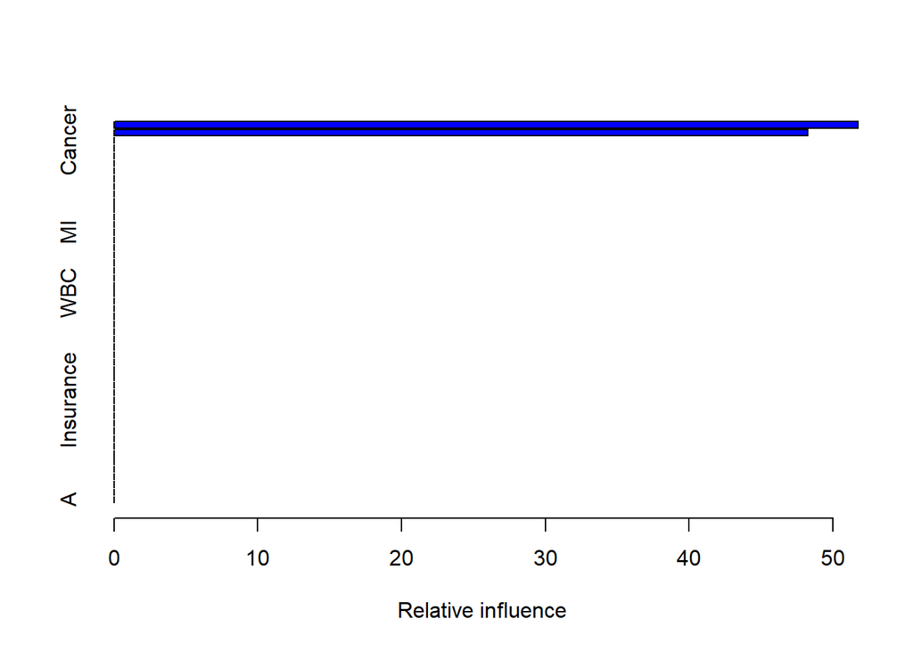

```
##                               var  rel.inf
## Disease.category Disease.category 51.74467
## DNR.status             DNR.status 48.25533
## Cancer                     Cancer  0.00000
## Cardiovascular     Cardiovascular  0.00000
## Congestive.HF       Congestive.HF  0.00000
## Dementia                 Dementia  0.00000
```

```r
gbmboost <- gbm(Y ∼ ., data = rhcdata, distribution = "gaussian", n.trees = 2, n.minobsinnode = 500/3, bag.fraction = 1, shrinkage=0.1)
head(summary(gbmboost))
```